# Exploring Mushrooms by Ninh Nguyen

When asked to think of a mushroom, you might imagine the following:

[figure not shown]

It's a beige, convex mushroom top with a uniform, thick stem. Maybe you thought of it cut up on a slice of delicious pizza or braised with sauce over rice. Regardless, you most likely did not consider this:

[figure not shown]

Mushrooms exist in a variety of different colors, shapes, sizes, textures, etc. In this project, I will analyze an extensive mushroom dataset from [UCI](https://archive.ics.uci.edu/ml/datasets/Mushroom) using bar charts and acquaint myself with the diverse array of mushrooms that exist worldwide.

## Looking Over the Data

   Read through this table to get a sense of the type(s) of variables in the data and the structure of the table. It may also be helpful to read through the information on [Kaggle](https://www.kaggle.com/uciml/mushroom-classification).

   Questions:
   - What type(s) of variables does **mushroom_data.csv** contain?
   - How many of the variables can we visualize effectively with a bar graph?

```python
# import libraries

import matplotlib.pyplot as plt

import pandas as pd

import seaborn as sns
```

```python
# load in the data

df = pd.read_csv("mushroom_data.csv")
df
```

|  | Class | Cap Shape | Cap Surface | Cap Color | Bruises | Odor | Gill Attachment | Gill Spacing | Gill Size | Gill Color | ... | Stalk Surface Below Ring | Stalk Color Above Ring | Stalk Color Below Ring | Veil Type | Veil Color | Ring Number | Ring Type | Spore Print Color | Population | Habitat |
| --- | --- | --- | --- | --- | --- | --- | --- | --- | --- | --- | --- | --- | --- | --- | --- | --- | --- | --- | --- | --- | --- |
| 0 | Poisonous | Convex | Smooth | Brown | True | Pungent | Free | Close | Narrow | Black | ... | Smooth | White | White | Partial | White | One | Pendant | Black | Scattered | Urban |
| 1 | Edible | Convex | Smooth | Yellow | True | Almond | Free | Close | Broad | Black | ... | Smooth | White | White | Partial | White | One | Pendant | Brown | Numerous | Grasses |
| 2 | Edible | Bell | Smooth | White | True | Anise | Free | Close | Broad | Brown | ... | Smooth | White | White | Partial | White | One | Pendant | Brown | Numerous | Meadows |
| 3 | Poisonous | Convex | Scaly | White | True | Pungent | Free | Close | Narrow | Brown | ... | Smooth | White | White | Partial | White | One | Pendant | Black | Scattered | Urban |
| 4 | Edible | Convex | Smooth | Gray | False | None | Free | Crowded | Broad | Black | ... | Smooth | White | White | Partial | White | One | Evanescent | Brown | Abundant | Grasses |
| ... | ... | ... | ... | ... | ... | ... | ... | ... | ... | ... | ... | ... | ... | ... | ... | ... | ... | ... | ... | ... | ... |
| 8119 | Edible | Knobbed | Smooth | Brown | False | None | Attached | Close | Broad | Yellow | ... | Smooth | Orange | Orange | Partial | Orange | One | Pendant | Buff | Clustered | Leaves |
| 8120 | Edible | Convex | Smooth | Brown | False | None | Attached | Close | Broad | Yellow | ... | Smooth | Orange | Orange | Partial | Brown | One | Pendant | Buff | Several | Leaves |
| 8121 | Edible | Flat | Smooth | Brown | False | None | Attached | Close | Broad | Brown | ... | Smooth | Orange | Orange | Partial | Orange | One | Pendant | Buff | Clustered | Leaves |
| 8122 | Poisonous | Knobbed | Scaly | Brown | False | Fishy | Free | Close | Narrow | Buff | ... | Silky | White | White | Partial | White | One | Evanescent | White | Several | Leaves |
| 8123 | Edible | Convex | Smooth | Brown | False | None | Attached | Close | Broad | Yellow | ... | Smooth | Orange | Orange | Partial | Orange | One | Pendant | Orange | Clustered | Leaves |

8124 rows × 23 columns

```python
# view the first 10 rows of the file

df.head(10)
```

|  | Class | Cap Shape | Cap Surface | Cap Color | Bruises | Odor | Gill Attachment | Gill Spacing | Gill Size | Gill Color | ... | Stalk Surface Below Ring | Stalk Color Above Ring | Stalk Color Below Ring | Veil Type | Veil Color | Ring Number | Ring Type | Spore Print Color | Population | Habitat |
| --- | --- | --- | --- | --- | --- | --- | --- | --- | --- | --- | --- | --- | --- | --- | --- | --- | --- | --- | --- | --- | --- |
| 0 | Poisonous | Convex | Smooth | Brown | True | Pungent | Free | Close | Narrow | Black | ... | Smooth | White | White | Partial | White | One | Pendant | Black | Scattered | Urban |
| 1 | Edible | Convex | Smooth | Yellow | True | Almond | Free | Close | Broad | Black | ... | Smooth | White | White | Partial | White | One | Pendant | Brown | Numerous | Grasses |
| 2 | Edible | Bell | Smooth | White | True | Anise | Free | Close | Broad | Brown | ... | Smooth | White | White | Partial | White | One | Pendant | Brown | Numerous | Meadows |
| 3 | Poisonous | Convex | Scaly | White | True | Pungent | Free | Close | Narrow | Brown | ... | Smooth | White | White | Partial | White | One | Pendant | Black | Scattered | Urban |
| 4 | Edible | Convex | Smooth | Gray | False | None | Free | Crowded | Broad | Black | ... | Smooth | White | White | Partial | White | One | Evanescent | Brown | Abundant | Grasses |
| 5 | Edible | Convex | Scaly | Yellow | True | Almond | Free | Close | Broad | Brown | ... | Smooth | White | White | Partial | White | One | Pendant | Black | Numerous | Grasses |
| 6 | Edible | Bell | Smooth | White | True | Almond | Free | Close | Broad | Gray | ... | Smooth | White | White | Partial | White | One | Pendant | Black | Numerous | Meadows |
| 7 | Edible | Bell | Scaly | White | True | Anise | Free | Close | Broad | Brown | ... | Smooth | White | White | Partial | White | One | Pendant | Brown | Scattered | Meadows |
| 8 | Poisonous | Convex | Scaly | White | True | Pungent | Free | Close | Narrow | Pink | ... | Smooth | White | White | Partial | White | One | Pendant | Black | Several | Grasses |
| 9 | Edible | Bell | Smooth | Yellow | True | Almond | Free | Close | Broad | Gray | ... | Smooth | White | White | Partial | White | One | Pendant | Black | Scattered | Meadows |

10 rows × 23 columns

1. There are 23 variables in this dataset (one for each column). One of them (the `Bruises` variable) has `True` or `False` responses. This will create problems when we try to plot this column later on.

   One way we can fix this issue is by converting each `True` and `False` value to a string. Iterate through the elements in the `Bruises` variable and convert each value to a string using the `str()` method.

   Now, all our variables are of `object` types, which means we can graph them. Graphing each one individually would be tedious; luckily, I will use loops.

   If you look at the code block below, you will see an attribute called `columns`. This attribute returns the name of each variable in **mushroom_data.csv**.
   - Create a loop that traverses each `column` in the `columns` list.
   - Print each `column` in `columns` while iterating through the loop. This is to check that your `for` loop is working correctly.

```python
# list of all column headers

for index in range(0,len(df['Bruises'])):
    df['Bruises'][index] = str(df['Bruises'][index])

columns = df.columns.tolist()

for column in columns:
    print(column)
```

```
Class
Cap Shape
Cap Surface
Cap Color
Bruises
Odor
Gill Attachment
Gill Spacing
Gill Size
Gill Color
Stalk Shape
Stalk Root
Stalk Surface Above Ring
Stalk Surface Below Ring
Stalk Color Above Ring
Stalk Color Below Ring
Veil Type
Veil Color
Ring Number
Ring Type
Spore Print Color
Population
Habitat
```

1. In the output above, you should see 23 column names pop up starting with `class` and ending with `habitat`.

   I can now plot the data using the `.countplot()` method from the seaborn library. Steps:
   - Call `.countplot()` in the `for` loop
   - Use `column` and the `df` pandas DataFrame to graph the value counts of each variable in **mushroom_data.csv**.

   Please wait until the next task to use `plt.show()`.

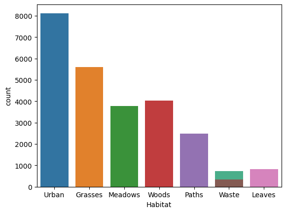

```python
for column in columns:
    sns.countplot(x=column,data=df)
```

1. At the end of your `for` loop, add the following lines of code to show your plots:

   ```
   plt.show()
   plt.clf()
   ```

   The `.show()` Matplotlib method should look familiar from the previous lesson, but [.clf()](https://matplotlib.org/3.1.1/api/_as_gen/matplotlib.pyplot.clf.html) might be unfamiliar. This method is also from the Matplotlib library. It clears any previous figure formatting. This will keep any graphs you are plotting from bunching up on each other. Instead, your plots will be neatly stacked on top of each other with spacing ideal for viewing.

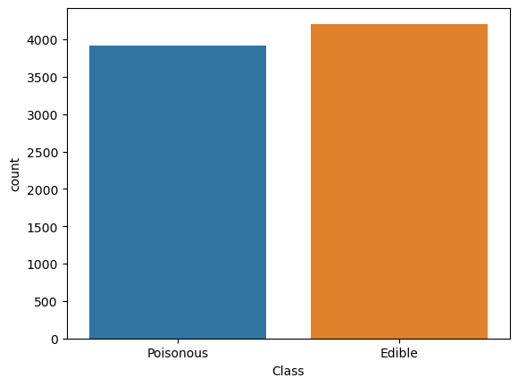

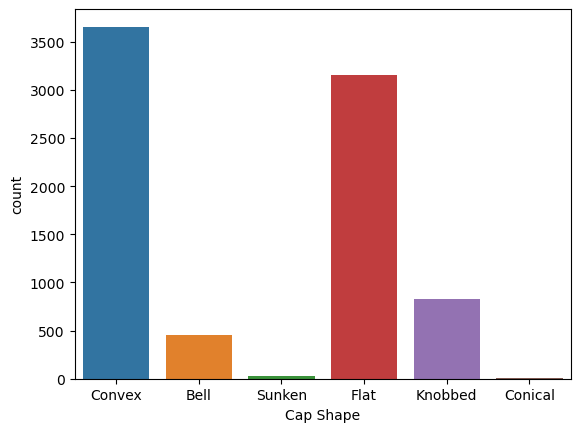

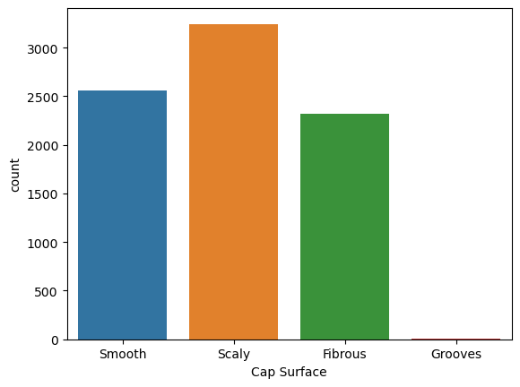

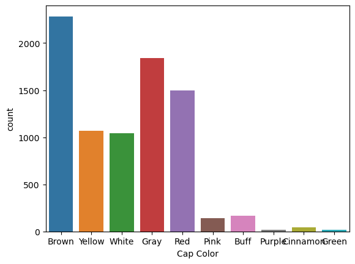

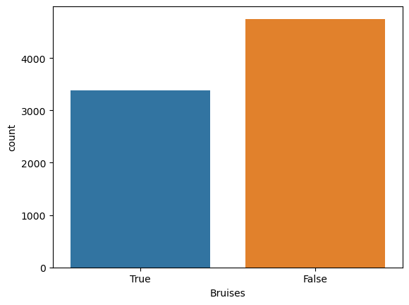

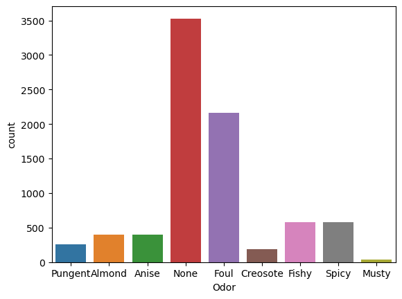

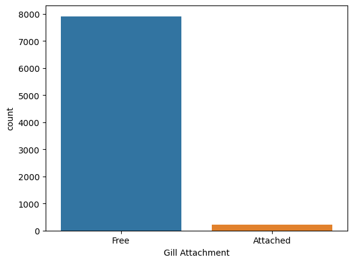

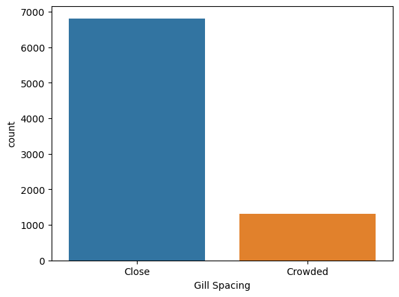

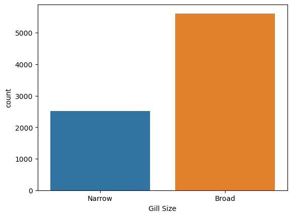

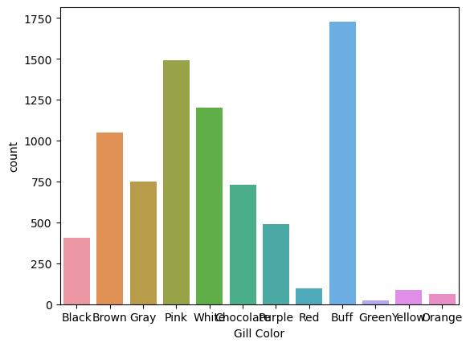

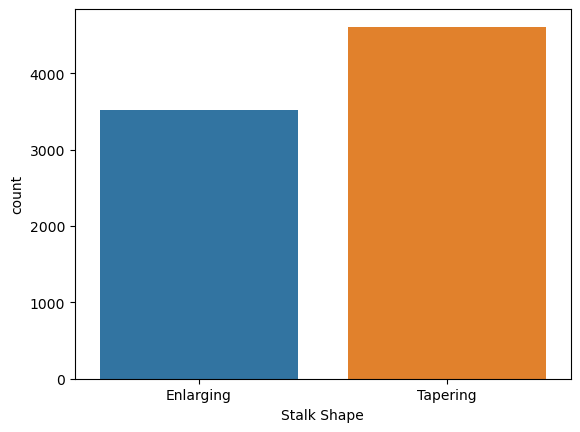

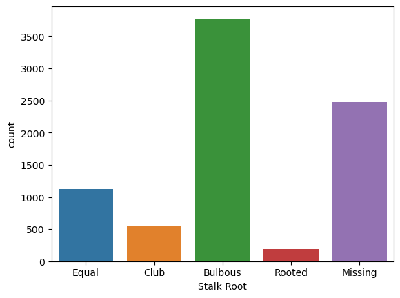

[11 more figures not shown]

```python
for column in columns:
    sns.countplot(x = df[column], data=df)
    plt.show()
    plt.clf()
```

1. After using `plt.show()` and `plt.clf()`, 23 plots should appear in the output below the previous code block.

   In the next few steps, I will clean up the graphs and make them more readable and useful for finding patterns.

## Cleaning the Bar Graphs

1. As you scroll through the graphs, you may notice some imperfections. For example, some of the x-axis labels overlap each other. The font size for the labels along the x-axis is also pretty small, making them tough to read.

   Let's fix these up with two lines of code.

   Following my `.countplot()` method, I add the following two lines of code in my `for` loop:

   ```
   # rotates the value labels slightly so they don't overlap, also slightly increases font size
   plt.xticks(rotation=30, fontsize=10)
   # increases the variable label font size slightly to increase readability
   plt.xlabel(column, fontsize=12)
   ```

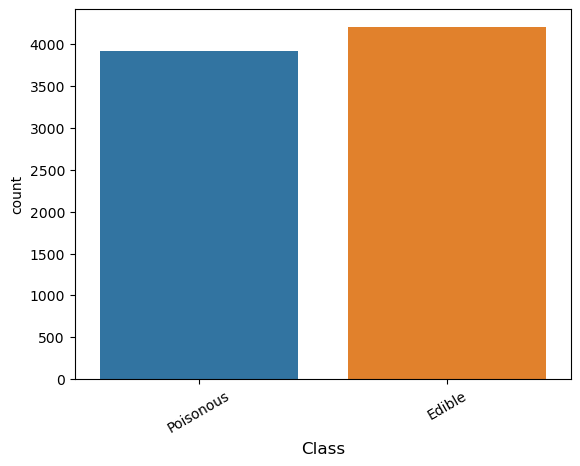

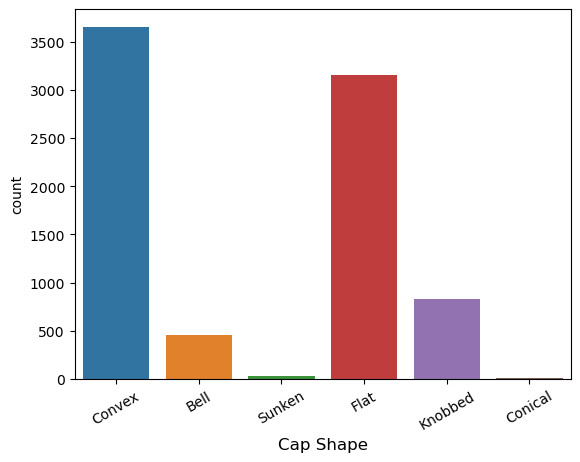

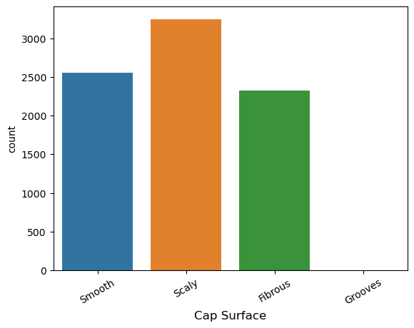

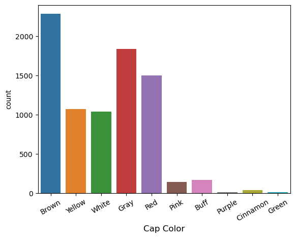

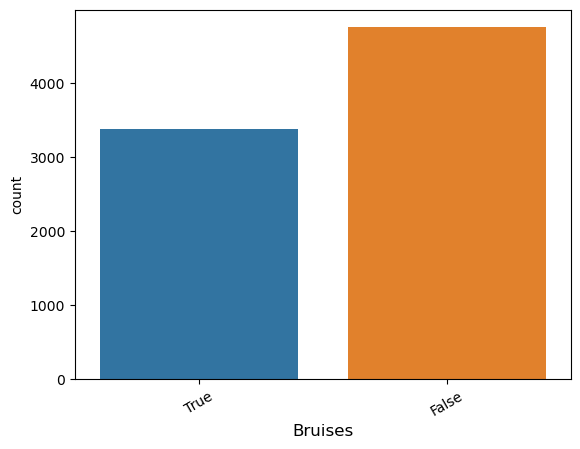

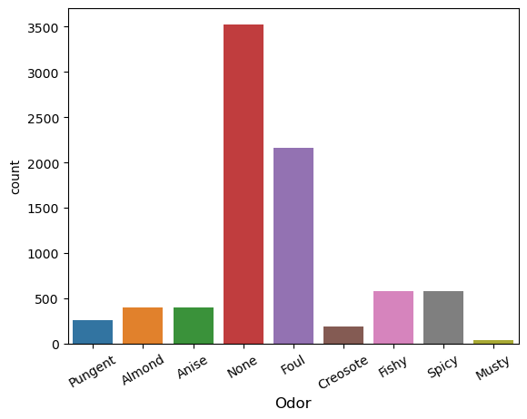

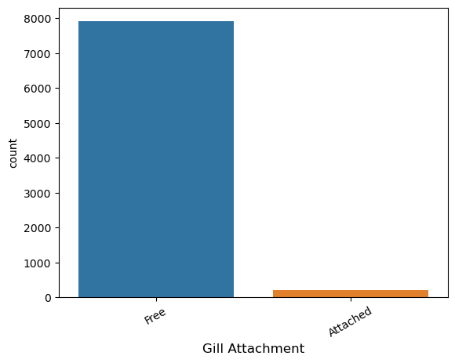

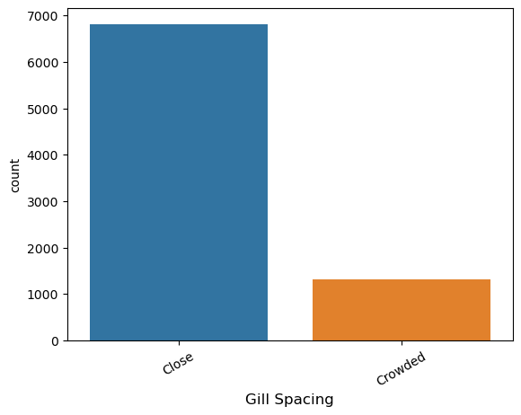

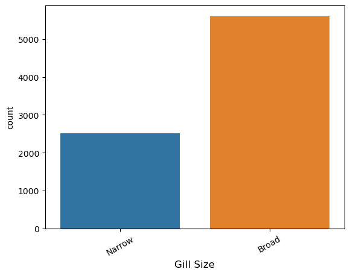

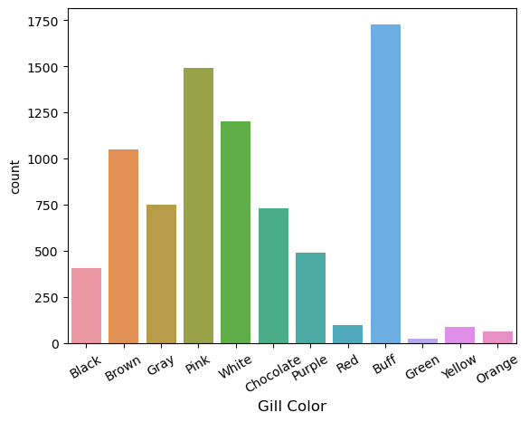

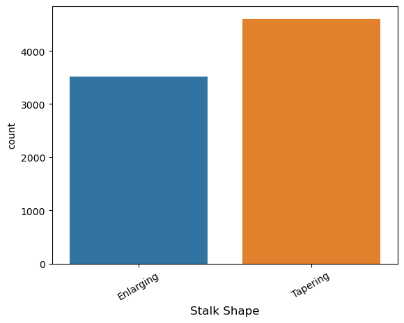

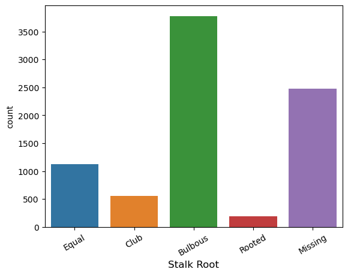

[11 more figures not shown]

```python
for column in columns:
    # print(column)
    sns.countplot(x = df[column], data=df)
    # rotates the value labels slightly so they don't overlap, also slightly increases font size
    plt.xticks(rotation=30, fontsize=10)
    # increases the variable label font size slightly to increase readability
    plt.xlabel(column, fontsize=12)
    plt.show()
    plt.clf()
```

1. One more thing I can do to increase readability is to add an informative title. Using `.title()` from the Matplotlib library, I give my graph the following title:

   ```
   {Variable Name} Value Counts
   ```